# Small analysis for Tiwari V. et al.

ChIP analysis

Eric Bautista Farrerons

First created on November 2024. Updated on 25 noviembre 2024

# 1 Read and understand data

I’ve been provided WIG files from a ChIP-Seq experiments, so the data is already preprocessed, representing the signal intensities across the genome. This indicates the enrichment of a protein of interest at specific genomic regions, in this case Phf21b.

```r
# Load packages and paths
library(here)
source(here::here("scripts", "install.R"))
source(here::here("scripts", "paths.R"))

# Read data
rep1_mesc_data <- import(here::here("data", "GSM2859278_Phf21b_ChIP_mESC_pDox_Replicate1.wig"), format = "wig")
rep2_mesc_data <- import(here::here("data", "GSM2859279_Phf21b_ChIP_mESC_pDox_Replicate2.wig"), format = "wig")
rep1_n2a_data <- import(here::here("data", "GSM2859280_Phf21b_ChIP_N2A_Day2_Diff_Replicate1.wig"), format = "wig")
input_n2a_data <- import(here::here("data", "GSM2859281_Phf21b_Input_N2A_Day2_Diff_Replicate1.wig"), format = "wig")

# Create path for results
chipseq_results_path <- file.path(results_path,
                          "./chipseq")
if (!dir.exists(chipseq_results_path)) {
  dir.create(chipseq_results_path, recursive = TRUE)
}
```

The data is already preprocessed using FastQC, bowtie for alignment with reference genome and indexed using SAMtools. Then WIG files were generated using QuasR.

# 2 Plots

## 2.1 Signal intensity on Genomic position of Phf21b

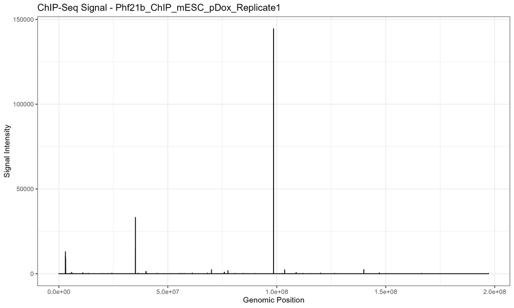

```r
samples <- list(
  "Phf21b_ChIP_mESC_pDox_Replicate1" = rep1_mesc_data,
  "Phf21b_ChIP_mESC_pDox_Replicate2" = rep2_mesc_data,
  "Phf21b_ChIP_N2A_Day2_Diff_Replicate1" = rep1_n2a_data,
  "Phf21b_Input_N2A_Day2_Diff_Replicate1" = input_n2a_data
)

# Plot 1
for (sample_name in names(samples)) {
  sample_data <- samples[[sample_name]]
  sample_df <- as.data.frame(sample_data)

  plot <- ggplot(sample_df, aes(x = start, y = score)) +
    geom_line() +
    theme_bw() +
    labs(title = paste("ChIP-Seq Signal -", sample_name),
         x = "Genomic Position",
         y = "Signal Intensity")

  # Save plot to results path
  ggsave(
    filename = file.path(chipseq_results_path, paste0(sample_name, "_signal_plot.png")),
    plot = plot,
    width = 10,
    height = 6
  )
}

# Display the PNG images
knitr::include_graphics(file.path(chipseq_results_path, "Phf21b_ChIP_mESC_pDox_Replicate1_signal_plot.png"))
```

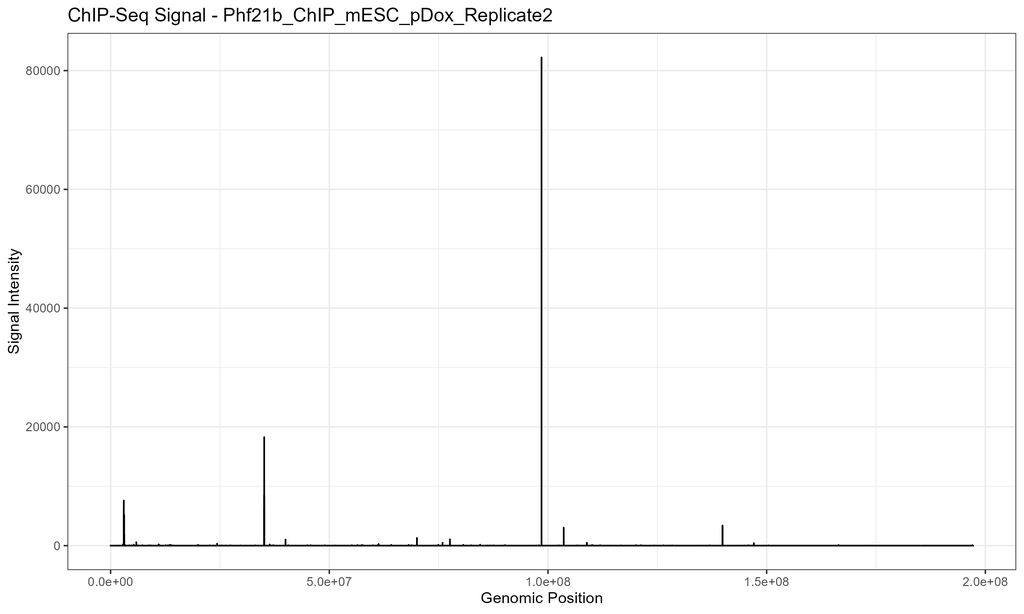

```r
knitr::include_graphics(file.path(chipseq_results_path, "Phf21b_ChIP_mESC_pDox_Replicate2_signal_plot.png"))
```

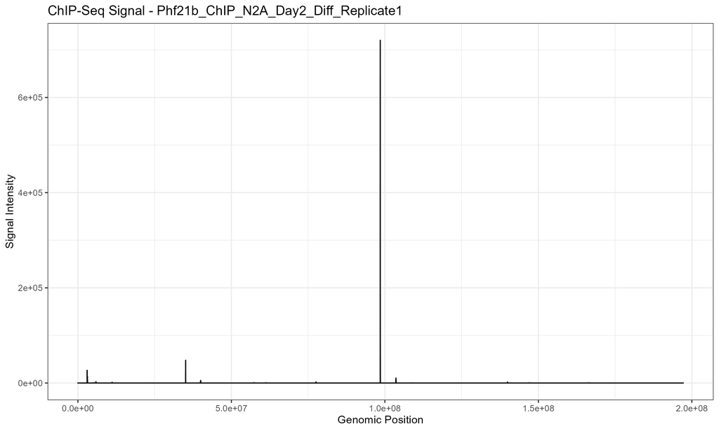

```r
knitr::include_graphics(file.path(chipseq_results_path, "Phf21b_ChIP_N2A_Day2_Diff_Replicate1_signal_plot.png"))
```

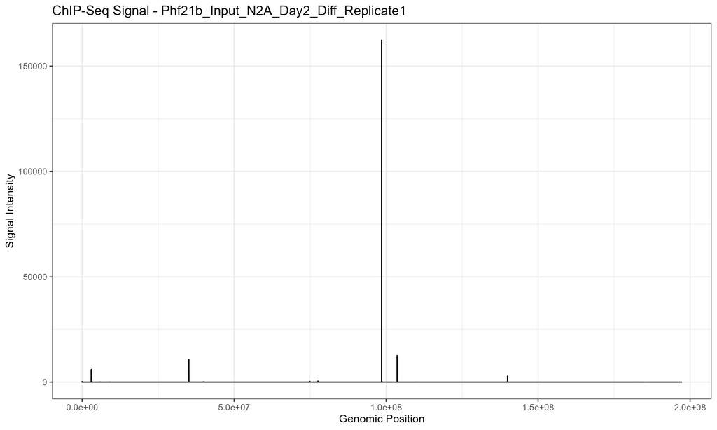

```r
knitr::include_graphics(file.path(chipseq_results_path, "Phf21b_Input_N2A_Day2_Diff_Replicate1_signal_plot.png"))
```

## 2.2 Genome Browser plots

I looked at the genomic positions of 4 cell cycle genes that cobound with Phf21b using the same mouse reference genome as in the paper ([mm9](https://genome-euro.ucsc.edu/cgi-bin/hgGateway?hgsid=346811084_67jGhvPsvKZEfT7s4Yho4M5mp0RQ)). Here is the list of genes analyzed:

1. Cdt1 - chr8:125091915-125097030
2. E2f1 - chr2:154385375-154395588
3. E2f7 - chr10:110182521-110224440
4. Mcm5 - chr8:77633427-77652338

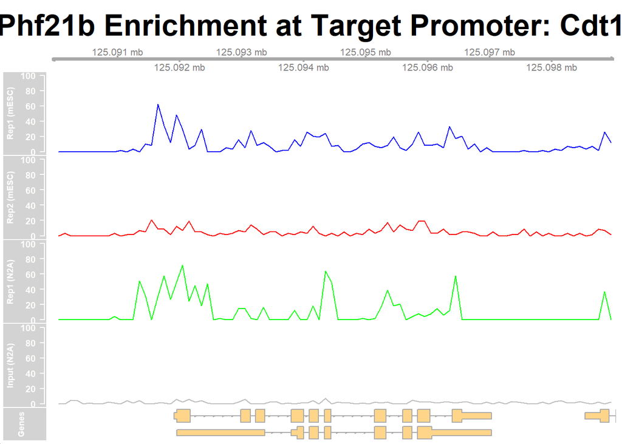

```r
# # Copy data
# rep1_mesc_copy <- copy(rep1_mesc_data)
# rep2_mesc_copy <- copy(rep2_mesc_data)
# rep1_n2a_copy <- copy(rep1_n2a_data)
# input_n2a_copy <- copy(input_n2a_data)

generate_chipseq_plot <- function(gene_name, chr_num, start_pos, end_pos, output_path) {

  # Target region
  target_region <- GRanges(seqnames = chr_num, ranges = IRanges(start = start_pos, end = end_pos))

  # Data tracks for each replicate and input
  track_rep1_mesc <- DataTrack(range = rep1_mesc_data,
                               genome = "mm9",
                               chromosome = chr_num,
                               name = "Rep1 (mESC)",
                               type = "l",
                               col = "blue",
                               ylim = c(0, 100))

  track_rep2_mesc <- DataTrack(range = rep2_mesc_data,
                               genome = "mm9",
                               chromosome = chr_num,
                               name = "Rep2 (mESC)",
                               type = "l",
                               col = "red",
                               ylim = c(0, 100))

  track_rep1_n2a <- DataTrack(range = rep1_n2a_data,
                              genome = "mm9",
                              chromosome = chr_num,
                              name = "Rep1 (N2A)",
                              type = "l",
                              col = "green",
                              ylim = c(0, 100))

  track_input_n2a <- DataTrack(range = input_n2a_data,
                               genome = "mm9",
                               chromosome = chr_num,
                               name = "Input (N2A)",
                               type = "l",
                               col = "gray",
                               ylim = c(0, 100))

  # Gene track
  axisTrack <- GenomeAxisTrack()
  gene_track <- GeneRegionTrack(TxDb.Mmusculus.UCSC.mm9.knownGene,
                                genome = "mm9",
                                chromosome = chr_num,
                                name = "Genes")

  # Plot
  plotTracks(list(axisTrack, track_rep1_mesc, track_rep2_mesc, track_rep1_n2a, track_input_n2a, gene_track),
             from = start_pos - 2000, to = end_pos + 2000,
             chromosome = chr_num, genome = "mm9",
             main = paste0("Phf21b Enrichment at Target Promoter: ", gene_name))

  # Save plot to PDF
  pdf(file.path(output_path, paste0("Phf21b_Enrichment_at_Target_Promoter_", gene_name, ".pdf")), width = 10, height = 6)
  plotTracks(list(axisTrack, track_rep1_mesc, track_rep2_mesc, track_rep1_n2a, track_input_n2a, gene_track),
             from = start_pos - 2000, to = end_pos + 2000,
             chromosome = chr_num, genome = "mm9",
             main = paste0("Phf21b Enrichment at Target Promoter: ", gene_name))
  dev.off()
}

generate_chipseq_plot("Cdt1", "chr8", 125091915, 125097030, chipseq_results_path)
```